# Week 9: Bears @ Cardinals Analysis

Author

Jacob Lukasik

Published

November 4, 2024

## Prepare dataframes

```r
game_df <- read.csv("bears_cards.csv")

game_df <- game_df %>%
  filter(Down %in% c(1, 2, 3, 4)) %>%
  mutate(PlayType = case_when(
    grepl("pass", Detail, ignore.case = TRUE) ~ "Pass",
    grepl("sack", Detail, ignore.case = TRUE) ~ "Sack",
    grepl("field goal", Detail, ignore.case = TRUE) ~ "FG",
    grepl("punt", Detail, ignore.case = TRUE) ~ "Punt",
    grepl("penalty", Detail, ignore.case = TRUE) ~ "Penalty",
    TRUE ~ "Run"  # This handles cases that don't match
  )) %>%
  mutate(YardGain = case_when(
    PlayType %in% c("FG", "Punt") ~ NA_integer_,
    TRUE ~ as.integer(str_extract(Detail, "-?\\d+"))
  ))
```

```r
run_game_df <- game_df %>%
  filter(PlayType == "Run") %>%
  filter(grepl("Caleb Williams|D'Andre Swift|Roschon Johnson", Detail, ignore.case = TRUE)) %>%
  mutate(YardGain = replace_na(YardGain, 0)) %>%
  mutate(RunLoc = case_when(
    grepl("left tackle", Detail, ignore.case = TRUE) ~ "LT",
    grepl("right tackle", Detail, ignore.case = TRUE) ~ "RT",
    grepl("middle", Detail, ignore.case = TRUE) ~ "Mid",
    grepl("kneel", Detail, ignore.case = TRUE) ~ "Kneel",
    grepl("left end", Detail, ignore.case = TRUE) ~ "LE",
    grepl("right end", Detail, ignore.case = TRUE) ~ "RE",
    TRUE ~ NA_character_  # Fallback for other cases
  ))
```

```r
pass_game_df <- game_df %>%
  filter(PlayType == "Pass") %>%
  filter(grepl("Caleb Williams", Detail, ignore.case = TRUE)) %>%
  filter(!grepl("no play", Detail, ignore.case = TRUE)) %>%  # Remove rows with "no play"
  mutate(PassLoc = case_when(
    grepl("short right", Detail, ignore.case = TRUE) ~ "SR",
    grepl("short middle", Detail, ignore.case = TRUE) ~ "SM",
    grepl("short left", Detail, ignore.case = TRUE) ~ "SL",
    grepl("deep right", Detail, ignore.case = TRUE) ~ "DR",
    grepl("deep middle", Detail, ignore.case = TRUE) ~ "DM",
    grepl("deep left", Detail, ignore.case = TRUE) ~ "DL",
    TRUE ~ NA_character_
  )) %>%
  mutate(YardGain = replace_na(YardGain, 0)) %>%
  mutate(Completed = if_else(grepl("incomplete", Detail, ignore.case = TRUE), 0, 1)) %>%
  mutate(EPA = as.numeric(gsub("\\\\", "", EPA.))) %>%
  select(-EPA.)
```

## Rushing yards by down

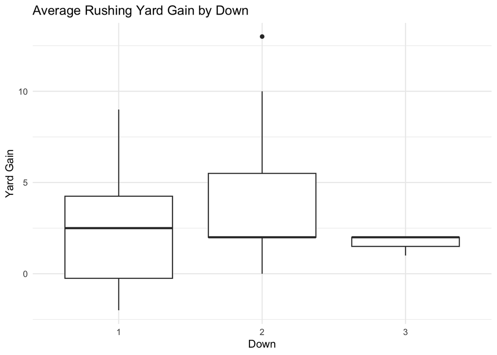

```r
ggplot(run_game_df, aes(x = factor(Down), y = YardGain)) +
  geom_boxplot() +
  labs(title = "Average Rushing Yard Gain by Down",
       x = "Down",
       y = "Yard Gain") +
  scale_x_discrete(limits = c("1", "2", "3")) +
  theme_minimal()
```

The bears severely underperformed on the ground on a Sunday that they really needed to show up. The carries on first down were somewhat all over the place but the 25th percentile being in the negatives and not one of the medians (between downs) even touching three is bad. For a team that averaged three yards a carry we can see why some of it all began to go wrong. We joined Indianapolis, LA Rams, Jacksonville, and Las Vegas in the bottom of the barrel for rush yards this week and we ran for just over half of our avg rush yards per game throughout the year. Doing this against the tenth worst rush defense in the league is inexcusable and the run game absolutely failed in igniting a spark for the rest of the team.

## Caleb heat map and location breakdown

```r
heatmap_data <- pass_game_df %>%
  group_by(PassLoc) %>%
  summarize(Average_YardGain = mean(YardGain, na.rm = TRUE)) %>%
  ungroup()

coordinates <- data.frame(
  PassLoc = c("DL", "DM", "DR", "SL", "SM", "SR"),
  x = c(1, 2, 3, 1, 2, 3),
  y = c(2, 2, 2, 1, 1, 1)
)

completion_stats <- pass_game_df %>%
  group_by(PassLoc) %>%
  summarise(
    TotalPasses = n(),
    CompletedPasses = sum(Completed),
    CompPct = CompletedPasses / TotalPasses * 100,
    Avg_EPA = mean(EPA - EPB, na.rm = TRUE)  # Calculate average EPA
  ) %>%
  ungroup()


plot_data <- left_join(coordinates, heatmap_data, by = "PassLoc") %>%
  left_join(completion_stats, by = "PassLoc")

completion_stats
```

```
# A tibble: 6 × 5
  PassLoc TotalPasses CompletedPasses CompPct Avg_EPA
  <chr>         <int>           <dbl>   <dbl>   <dbl>
1 DL                7               1    14.3 -0.0629
2 DM                1               0     0   -0.54
3 DR                1               0     0   -0.54
4 SL                7               2    28.6 -0.654
5 SM                5               5   100    0.906
6 SR               21              14    66.7  0.227
```

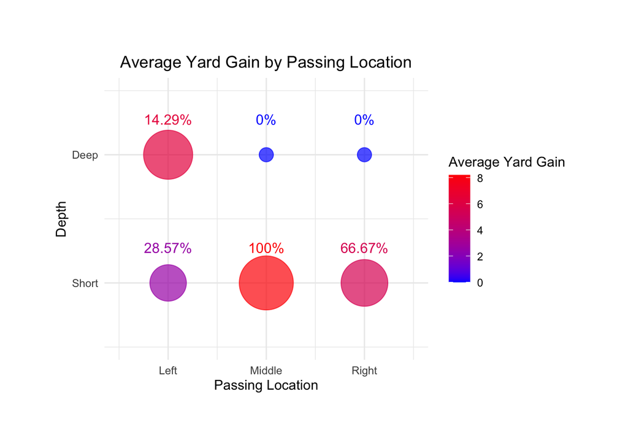

```r
ggplot(plot_data, aes(x = x, y = y, size = Average_YardGain, label = PassLoc, color = Average_YardGain)) +
  geom_point(alpha = 0.7) +
  geom_text(aes(label = paste0(round(CompPct, 2), "%")), vjust = -3, size = 4) +
  scale_size(range = c(5, 20), guide = "none") +
  scale_color_gradient(low = "blue", high = "red", name = "Average Yard Gain") +
  scale_x_continuous(breaks = 1:3, labels = c("Left", "Middle", "Right"), limits = c(0.5, 3.5)) +
  scale_y_continuous(breaks = 1:2, labels = c("Short", "Deep"), limits = c(0.5, 2.5)) +
  labs(title = "Average Yard Gain by Passing Location",
       x = "Passing Location",
       y = "Depth") +
  theme_minimal() +
  theme(plot.title = element_text(hjust = 0.5),
        plot.margin = margin(45, 45, 45, 45))
```

Caleb’s passing chart was subpar to say the least. It is frustrating to watch him struggle deep as well as the refusal to utilize our superstar TE in Caleb’s best zones. (The deep left bubble is somewhat exaggerated from Odunze’s deep gain, also Caleb’s only deep completion). Caleb also had an averaged negative EPA (Expected Points Added) in every zone but short right and short middle passes, which just makes it all the more confusing that we got nothing from Kmet. At the end of the day, football is a momentum game, when the play calling refuses to let our offense get in a rhythm you understand why not only this game went the way it, but last weekend against Washington as well.

## Down by down breakdown of the passsing game

```r
down_counts <- pass_game_df %>%
  group_by(PassLoc, Down) %>%
  summarise(Count = n(), .groups = "drop")

down_breakdown <- down_counts %>%
  pivot_wider(names_from = Down, values_from = Count,
              values_fill = list(Count = 0),
              names_prefix = "Down_")

colnames(down_breakdown)[-1] <- c("First", "Second", "Third", "Fourth")

down_breakdown <- down_breakdown %>%
  mutate(Total = First + Second + Third + Fourth)

down_breakdown
```

```
# A tibble: 6 × 6
  PassLoc First Second Third Fourth Total
  <chr>   <int>  <int> <int>  <int> <int>
1 DL          2      3     2      0     7
2 DM          1      0     0      0     1
3 DR          1      0     0      0     1
4 SL          1      1     4      1     7
5 SM          1      2     1      1     5
6 SR          7     11     2      1    21
```

Avg 3rd down yardage:

```r
average_togo_third_down <- pass_game_df %>%
  filter(Down == 3) %>%
  summarise(Avg_ToGo = mean(ToGo, na.rm = TRUE))
average_togo_third_down
```

```
  Avg_ToGo
1 9.333333
```

## Mean running gains by location

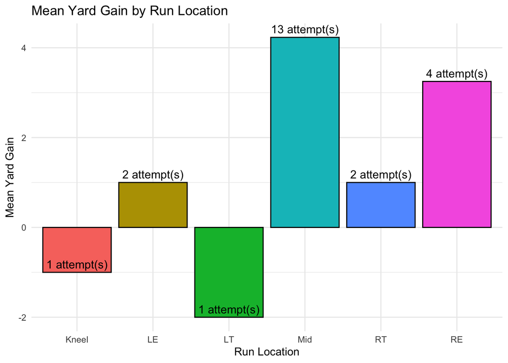

```r
run_stats <- run_game_df %>%
  group_by(RunLoc) %>%
  summarise(
    Mean_YardGain = mean(YardGain, na.rm = TRUE),
    Frequency = n()
  )

run_stats$RunLoc <- factor(run_stats$RunLoc, levels = c("Kneel", "LE", "LT", "Mid", "RT", "RE"))

# Create the bar graph
ggplot(run_stats, aes(x = RunLoc, y = Mean_YardGain, fill = RunLoc)) +
  geom_bar(stat = "identity", color = "black") +
  geom_text(aes(label = paste0(Frequency, " attempt(s)")), vjust = -0.5, size = 4) +
  labs(title = "Mean Yard Gain by Run Location",
       x = "Run Location",
       y = "Mean Yard Gain") +
  theme_minimal() +
  theme(legend.position = "none")
```

The somewhat good news was that the run game seemed to have stayed somewhat alright. We targeted the best spots on the field consistently and didn’t try to keep running the ball where it wasn’t clicking, but 3 yds/rush is not going to win us games and 3.4 overall yds/ play is an issue.

Overall, the Bears fell flat because of horrible offensive playcalling and a defense in shambles. The defense had their streak of not allowing more than 21 points in a game snapped to a team who averaged 22.75 pts/game coming into Sunday’s matchup. It is abundantly clear that the Bears biggest enemy right now is themselves and next weekend against the Pats is extremely important to gain back some confidence & rhythm before we play the Packers.